# Shiny Application and Reproducible Pitch

Luis Amigo

12 September 2018

## Course Project

This document is a small summary and usage guide of the shiny app created for the project.

### Objective

Main target of the app is showing in an interactive manner data from attacks to a group of webservers.

Data is gotten from fail2ban actions, so they are categorized by the action that triggered fail2ban.

It is beyond this presentation explaining how fail2ban works and the nature of actions scripts is private.

## Data Summary

Data has five columns:

- Latitude and Longitude are the coordinates
- Action is the action that triggered ban
- asn is the ASN number of the originating ISP
- org is the text name registered for that ASN

```
##     latitude        longitude              asn
##  Min.   :-46.49   Min.   :-123.963   AS16276 : 308
##  1st Qu.: 21.03   1st Qu.:   2.339   AS4837  : 269
##  Median : 37.51   Median :  34.703   AS135905: 154
##  Mean   : 31.02   Mean   :  41.971   AS4134  : 130
##  3rd Qu.: 46.00   3rd Qu.: 114.133   AS45090 :  65
##  Max.   : 65.00   Max.   : 178.417   AS4766  :  65
##                                      (Other) :2235
##                                                 org             action
##  OVH SAS                                          : 308   ssh      :1730
##  CHINA UNICOM China169 Backbone                   : 269   wp-login : 831
##  VIETNAM POSTS AND TELECOMMUNICATIONS GROUP       : 154   f2b-loop2: 268
##  No.31,Jin-rong Street                            : 130   f2b-loop3: 213
##  Korea Telecom                                    :  65   default  :  68
##  Shenzhen Tencent Computer Systems Company Limited:  65   davical  :  58
##  (Other)                                          :2235   (Other)  :  58
```

## Shiny App

Here you can see the structure of the app:

- On the left panel you can select the actions that you want to be displayed
- On the main content you can see the map representation of the points using leaflet. Data is clustered and will uncluster if you zoom enough

[figure not shown]

## Selecting Data

Use the checkboxes to select the actions you want to display

Click on “Refresh Map” to reload the data

Once you zoom enough and data is unclustered, hover on the marker to see the org details

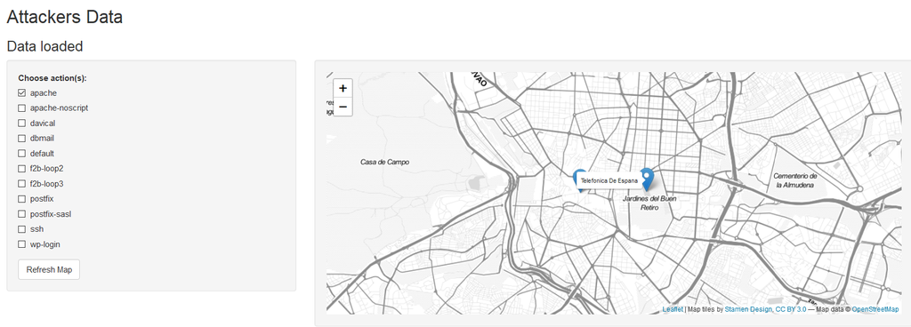